# Risk Factor Analysis

## Outcome Variable

**Outcome Variable:** y_rate_haz

## Predictor Variables

**Intervention Variable:** single

**Adjustment Set:**

- arm
- W_mage
- W_fage
- meducyrs
- feducyrs
- W_mhtcm
- W_mwtkg
- W_mbmi
- delta_W_mage
- delta_W_fage
- delta_meducyrs
- delta_feducyrs
- delta_W_mhtcm
- delta_W_mwtkg
- delta_W_mbmi

## Stratifying Variables

The analysis was stratified on these variable(s):

- agecat
- studyid
- country

## Data Summary

| agecat | studyid | country | single | n_cell | n |
| --- | --- | --- | --- | --- | --- |
| 0-3 months | ki0047075b-MAL-ED | BANGLADESH | 0 | 244 | 244 |
| 0-3 months | ki0047075b-MAL-ED | BANGLADESH | 1 | 0 | 244 |
| 0-3 months | ki0047075b-MAL-ED | BRAZIL | 0 | 157 | 180 |
| 0-3 months | ki0047075b-MAL-ED | BRAZIL | 1 | 23 | 180 |
| 0-3 months | ki0047075b-MAL-ED | INDIA | 0 | 200 | 200 |
| 0-3 months | ki0047075b-MAL-ED | INDIA | 1 | 0 | 200 |
| 0-3 months | ki0047075b-MAL-ED | NEPAL | 0 | 175 | 175 |
| 0-3 months | ki0047075b-MAL-ED | NEPAL | 1 | 0 | 175 |
| 0-3 months | ki0047075b-MAL-ED | PERU | 0 | 238 | 271 |
| 0-3 months | ki0047075b-MAL-ED | PERU | 1 | 33 | 271 |
| 0-3 months | ki0047075b-MAL-ED | SOUTH AFRICA | 0 | 131 | 229 |
| 0-3 months | ki0047075b-MAL-ED | SOUTH AFRICA | 1 | 98 | 229 |
| 0-3 months | ki0047075b-MAL-ED | TANZANIA, UNITED REPUBLIC OF | 0 | 220 | 229 |
| 0-3 months | ki0047075b-MAL-ED | TANZANIA, UNITED REPUBLIC OF | 1 | 9 | 229 |
| 0-3 months | ki1119695-PROBIT | BELARUS | 0 | 12251 | 12745 |
| 0-3 months | ki1119695-PROBIT | BELARUS | 1 | 494 | 12745 |
| 0-3 months | ki1126311-ZVITAMBO | ZIMBABWE | 0 | 7344 | 7835 |
| 0-3 months | ki1126311-ZVITAMBO | ZIMBABWE | 1 | 491 | 7835 |
| 0-3 months | ki1135781-COHORTS | GUATEMALA | 0 | 632 | 676 |
| 0-3 months | ki1135781-COHORTS | GUATEMALA | 1 | 44 | 676 |
| 0-3 months | ki1135781-COHORTS | INDIA | 0 | 4655 | 4662 |
| 0-3 months | ki1135781-COHORTS | INDIA | 1 | 7 | 4662 |
| 3-6 months | ki0047075b-MAL-ED | BANGLADESH | 0 | 231 | 231 |
| 3-6 months | ki0047075b-MAL-ED | BANGLADESH | 1 | 0 | 231 |
| 3-6 months | ki0047075b-MAL-ED | BRAZIL | 0 | 178 | 208 |
| 3-6 months | ki0047075b-MAL-ED | BRAZIL | 1 | 30 | 208 |
| 3-6 months | ki0047075b-MAL-ED | INDIA | 0 | 227 | 227 |
| 3-6 months | ki0047075b-MAL-ED | INDIA | 1 | 0 | 227 |
| 3-6 months | ki0047075b-MAL-ED | NEPAL | 0 | 233 | 233 |
| 3-6 months | ki0047075b-MAL-ED | NEPAL | 1 | 0 | 233 |

[output cut: 70 more lines]

The following strata were considered:

- agecat: 0-3 months, studyid: ki0047075b-MAL-ED, country: BANGLADESH
- agecat: 0-3 months, studyid: ki0047075b-MAL-ED, country: BRAZIL
- agecat: 0-3 months, studyid: ki0047075b-MAL-ED, country: INDIA
- agecat: 0-3 months, studyid: ki0047075b-MAL-ED, country: NEPAL
- agecat: 0-3 months, studyid: ki0047075b-MAL-ED, country: PERU
- agecat: 0-3 months, studyid: ki0047075b-MAL-ED, country: SOUTH AFRICA
- agecat: 0-3 months, studyid: ki0047075b-MAL-ED, country: TANZANIA, UNITED REPUBLIC OF
- agecat: 0-3 months, studyid: ki1119695-PROBIT, country: BELARUS
- agecat: 0-3 months, studyid: ki1126311-ZVITAMBO, country: ZIMBABWE
- agecat: 0-3 months, studyid: ki1135781-COHORTS, country: GUATEMALA
- agecat: 0-3 months, studyid: ki1135781-COHORTS, country: INDIA
- agecat: 12-24 months, studyid: ki0047075b-MAL-ED, country: BANGLADESH
- agecat: 12-24 months, studyid: ki0047075b-MAL-ED, country: BRAZIL
- agecat: 12-24 months, studyid: ki0047075b-MAL-ED, country: INDIA
- agecat: 12-24 months, studyid: ki0047075b-MAL-ED, country: NEPAL
- agecat: 12-24 months, studyid: ki0047075b-MAL-ED, country: PERU
- agecat: 12-24 months, studyid: ki0047075b-MAL-ED, country: SOUTH AFRICA
- agecat: 12-24 months, studyid: ki0047075b-MAL-ED, country: TANZANIA, UNITED REPUBLIC OF
- agecat: 12-24 months, studyid: ki1066203-TanzaniaChild2, country: TANZANIA, UNITED REPUBLIC OF
- agecat: 12-24 months, studyid: ki1119695-PROBIT, country: BELARUS
- agecat: 12-24 months, studyid: ki1126311-ZVITAMBO, country: ZIMBABWE
- agecat: 12-24 months, studyid: ki1135781-COHORTS, country: GUATEMALA
- agecat: 12-24 months, studyid: ki1135781-COHORTS, country: INDIA
- agecat: 12-24 months, studyid: ki1135781-COHORTS, country: PHILIPPINES
- agecat: 3-6 months, studyid: ki0047075b-MAL-ED, country: BANGLADESH
- agecat: 3-6 months, studyid: ki0047075b-MAL-ED, country: BRAZIL
- agecat: 3-6 months, studyid: ki0047075b-MAL-ED, country: INDIA
- agecat: 3-6 months, studyid: ki0047075b-MAL-ED, country: NEPAL
- agecat: 3-6 months, studyid: ki0047075b-MAL-ED, country: PERU
- agecat: 3-6 months, studyid: ki0047075b-MAL-ED, country: SOUTH AFRICA
- agecat: 3-6 months, studyid: ki0047075b-MAL-ED, country: TANZANIA, UNITED REPUBLIC OF
- agecat: 3-6 months, studyid: ki1066203-TanzaniaChild2, country: TANZANIA, UNITED REPUBLIC OF
- agecat: 3-6 months, studyid: ki1119695-PROBIT, country: BELARUS
- agecat: 3-6 months, studyid: ki1126311-ZVITAMBO, country: ZIMBABWE
- agecat: 3-6 months, studyid: ki1135781-COHORTS, country: GUATEMALA
- agecat: 3-6 months, studyid: ki1135781-COHORTS, country: INDIA
- agecat: 6-12 months, studyid: ki0047075b-MAL-ED, country: BANGLADESH
- agecat: 6-12 months, studyid: ki0047075b-MAL-ED, country: BRAZIL
- agecat: 6-12 months, studyid: ki0047075b-MAL-ED, country: INDIA
- agecat: 6-12 months, studyid: ki0047075b-MAL-ED, country: NEPAL
- agecat: 6-12 months, studyid: ki0047075b-MAL-ED, country: PERU
- agecat: 6-12 months, studyid: ki0047075b-MAL-ED, country: SOUTH AFRICA
- agecat: 6-12 months, studyid: ki0047075b-MAL-ED, country: TANZANIA, UNITED REPUBLIC OF
- agecat: 6-12 months, studyid: ki1066203-TanzaniaChild2, country: TANZANIA, UNITED REPUBLIC OF
- agecat: 6-12 months, studyid: ki1112895-Guatemala BSC, country: GUATEMALA
- agecat: 6-12 months, studyid: ki1119695-PROBIT, country: BELARUS
- agecat: 6-12 months, studyid: ki1126311-ZVITAMBO, country: ZIMBABWE
- agecat: 6-12 months, studyid: ki1135781-COHORTS, country: GUATEMALA
- agecat: 6-12 months, studyid: ki1135781-COHORTS, country: INDIA
- agecat: 6-12 months, studyid: ki1135781-COHORTS, country: PHILIPPINES

### Dropped Strata

Some strata were dropped due to rare outcomes:

- agecat: 0-3 months, studyid: ki0047075b-MAL-ED, country: BANGLADESH
- agecat: 0-3 months, studyid: ki0047075b-MAL-ED, country: INDIA
- agecat: 0-3 months, studyid: ki0047075b-MAL-ED, country: NEPAL
- agecat: 3-6 months, studyid: ki0047075b-MAL-ED, country: BANGLADESH
- agecat: 3-6 months, studyid: ki0047075b-MAL-ED, country: INDIA
- agecat: 3-6 months, studyid: ki0047075b-MAL-ED, country: NEPAL
- agecat: 6-12 months, studyid: ki0047075b-MAL-ED, country: BANGLADESH
- agecat: 6-12 months, studyid: ki0047075b-MAL-ED, country: INDIA
- agecat: 6-12 months, studyid: ki0047075b-MAL-ED, country: NEPAL
- agecat: 12-24 months, studyid: ki0047075b-MAL-ED, country: BANGLADESH
- agecat: 12-24 months, studyid: ki0047075b-MAL-ED, country: INDIA
- agecat: 12-24 months, studyid: ki0047075b-MAL-ED, country: NEPAL
- agecat: 12-24 months, studyid: ki1066203-TanzaniaChild2, country: TANZANIA, UNITED REPUBLIC OF

## Methods Detail

We’re interested in the causal parameters $E[Y_a]$ for all values of $a \in \mathcal{A}$. These parameters represent the mean outcome if, possibly contrary to fact, we intervened to set all units to have $A=a$. Under the randomization and positivity assumptions, these are identified by the statistical parameters $\psi_a=E_W[E_{Y|A,W}(Y|A=a,W)]$. In addition, we’re interested in the mean of $Y$, $E[Y]$ under no intervention (the observed mean). We will estimate these parameters by using SuperLearner to fit the relevant likelihood factors – $E_{Y|A,W}(Y|A=a,W)$ and $p(A=a|W)$, and then updating our likelihood fit using a joint TMLE.

For unadjusted analyses ($W=\{\}$), initial likelihoods were estimated using Lrnr_glm to estimate the simple $E(Y|A)$ and Lrnr_mean to estimate $p(A)$. For adjusted analyses, a small library containing Lrnr_glmnet, Lrnr_xgboost, and Lrnr_mean was used.

Having estimated these parameters, we will then use the delta method to estimate relative risks and attributable risks relative to a prespecified baseline level of $A$.

# Results Detail

## Results Plots

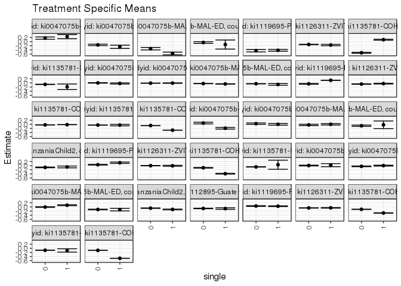

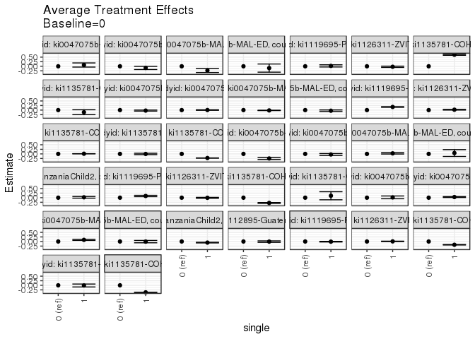

## Results Table

### Parameter: TSM

| agecat | studyid | country | intervention_level | baseline_level | estimate | ci_lower | ci_upper |
| --- | --- | --- | --- | --- | --- | --- | --- |
| 0-3 months | ki0047075b-MAL-ED | BRAZIL | 0 | NA | 0.1724588 | 0.1170276 | 0.2278900 |
| 0-3 months | ki0047075b-MAL-ED | BRAZIL | 1 | NA | 0.2425290 | 0.1424485 | 0.3426095 |
| 0-3 months | ki0047075b-MAL-ED | PERU | 0 | NA | -0.1586586 | -0.1932927 | -0.1240245 |
| 0-3 months | ki0047075b-MAL-ED | PERU | 1 | NA | -0.2494166 | -0.3289358 | -0.1698974 |
| 0-3 months | ki0047075b-MAL-ED | SOUTH AFRICA | 0 | NA | -0.3418123 | -0.4008343 | -0.2827904 |
| 0-3 months | ki0047075b-MAL-ED | SOUTH AFRICA | 1 | NA | -0.5727818 | -0.6378930 | -0.5076706 |
| 0-3 months | ki0047075b-MAL-ED | TANZANIA, UNITED REPUBLIC OF | 0 | NA | -0.0422918 | -0.0813576 | -0.0032261 |
| 0-3 months | ki0047075b-MAL-ED | TANZANIA, UNITED REPUBLIC OF | 1 | NA | -0.1408850 | -0.3605068 | 0.0787368 |
| 0-3 months | ki1119695-PROBIT | BELARUS | 0 | NA | -0.4409614 | -0.4988520 | -0.3830708 |
| 0-3 months | ki1119695-PROBIT | BELARUS | 1 | NA | -0.4203453 | -0.4639112 | -0.3767794 |
| 0-3 months | ki1126311-ZVITAMBO | ZIMBABWE | 0 | NA | -0.1384204 | -0.1490574 | -0.1277835 |
| 0-3 months | ki1126311-ZVITAMBO | ZIMBABWE | 1 | NA | -0.1646724 | -0.1972924 | -0.1320525 |
| 0-3 months | ki1135781-COHORTS | GUATEMALA | 0 | NA | -0.5388824 | -0.5620220 | -0.5157429 |
| 0-3 months | ki1135781-COHORTS | GUATEMALA | 1 | NA | 0.0936502 | 0.0709729 | 0.1163276 |
| 0-3 months | ki1135781-COHORTS | INDIA | 0 | NA | -0.0694702 | -0.0777192 | -0.0612212 |
| 0-3 months | ki1135781-COHORTS | INDIA | 1 | NA | -0.1853970 | -0.3193588 | -0.0514352 |
| 3-6 months | ki0047075b-MAL-ED | BRAZIL | 0 | NA | 0.0586933 | 0.0197667 | 0.0976199 |
| 3-6 months | ki0047075b-MAL-ED | BRAZIL | 1 | NA | -0.1909988 | -0.2330591 | -0.1489385 |
| 3-6 months | ki0047075b-MAL-ED | PERU | 0 | NA | 0.0301750 | -0.0027847 | 0.0631348 |
| 3-6 months | ki0047075b-MAL-ED | PERU | 1 | NA | -0.0015332 | -0.0425910 | 0.0395246 |
| 3-6 months | ki0047075b-MAL-ED | SOUTH AFRICA | 0 | NA | -0.0301377 | -0.0618723 | 0.0015970 |
| 3-6 months | ki0047075b-MAL-ED | SOUTH AFRICA | 1 | NA | -0.0008417 | -0.0352409 | 0.0335575 |
| 3-6 months | ki0047075b-MAL-ED | TANZANIA, UNITED REPUBLIC OF | 0 | NA | -0.0721021 | -0.1047651 | -0.0394391 |
| 3-6 months | ki0047075b-MAL-ED | TANZANIA, UNITED REPUBLIC OF | 1 | NA | -0.0255782 | -0.2091445 | 0.1579880 |
| 3-6 months | ki1066203-TanzaniaChild2 | TANZANIA, UNITED REPUBLIC OF | 0 | NA | -0.0867358 | -0.1040274 | -0.0694441 |
| 3-6 months | ki1066203-TanzaniaChild2 | TANZANIA, UNITED REPUBLIC OF | 1 | NA | -0.0650146 | -0.1084936 | -0.0215355 |
| 3-6 months | ki1119695-PROBIT | BELARUS | 0 | NA | 0.0438301 | 0.0247601 | 0.0629001 |
| 3-6 months | ki1119695-PROBIT | BELARUS | 1 | NA | 0.1370929 | 0.1034973 | 0.1706885 |
| 3-6 months | ki1126311-ZVITAMBO | ZIMBABWE | 0 | NA | -0.0025855 | -0.0122084 | 0.0070373 |
| 3-6 months | ki1126311-ZVITAMBO | ZIMBABWE | 1 | NA | -0.0092990 | -0.0328914 | 0.0142933 |
| 3-6 months | ki1135781-COHORTS | GUATEMALA | 0 | NA | -0.1052707 | -0.1206272 | -0.0899142 |
| 3-6 months | ki1135781-COHORTS | GUATEMALA | 1 | NA | -0.3915631 | -0.4093180 | -0.3738083 |
| 3-6 months | ki1135781-COHORTS | INDIA | 0 | NA | -0.0632424 | -0.0696888 | -0.0567960 |
| 3-6 months | ki1135781-COHORTS | INDIA | 1 | NA | 0.0429801 | -0.1774334 | 0.2633936 |
| 6-12 months | ki0047075b-MAL-ED | BRAZIL | 0 | NA | 0.0041078 | -0.0148893 | 0.0231050 |
| 6-12 months | ki0047075b-MAL-ED | BRAZIL | 1 | NA | 0.0219323 | -0.0521503 | 0.0960149 |
| 6-12 months | ki0047075b-MAL-ED | PERU | 0 | NA | -0.0357197 | -0.0508001 | -0.0206394 |
| 6-12 months | ki0047075b-MAL-ED | PERU | 1 | NA | -0.0002174 | -0.0208353 | 0.0204004 |
| 6-12 months | ki0047075b-MAL-ED | SOUTH AFRICA | 0 | NA | -0.0061048 | -0.0233867 | 0.0111771 |
| 6-12 months | ki0047075b-MAL-ED | SOUTH AFRICA | 1 | NA | 0.0842377 | 0.0624815 | 0.1059939 |
| 6-12 months | ki0047075b-MAL-ED | TANZANIA, UNITED REPUBLIC OF | 0 | NA | -0.1238574 | -0.1398522 | -0.1078625 |
| 6-12 months | ki0047075b-MAL-ED | TANZANIA, UNITED REPUBLIC OF | 1 | NA | -0.1296884 | -0.1924653 | -0.0669116 |
| 6-12 months | ki1066203-TanzaniaChild2 | TANZANIA, UNITED REPUBLIC OF | 0 | NA | -0.0604891 | -0.0699687 | -0.0510096 |
| 6-12 months | ki1066203-TanzaniaChild2 | TANZANIA, UNITED REPUBLIC OF | 1 | NA | -0.1203952 | -0.1377135 | -0.1030769 |
| 6-12 months | ki1112895-Guatemala BSC | GUATEMALA | 0 | NA | -0.0747209 | -0.0884798 | -0.0609621 |
| 6-12 months | ki1112895-Guatemala BSC | GUATEMALA | 1 | NA | -0.0799764 | -0.1184700 | -0.0414828 |
| 6-12 months | ki1119695-PROBIT | BELARUS | 0 | NA | 0.0443622 | 0.0281789 | 0.0605454 |
| 6-12 months | ki1119695-PROBIT | BELARUS | 1 | NA | 0.0357340 | 0.0198452 | 0.0516228 |
| 6-12 months | ki1126311-ZVITAMBO | ZIMBABWE | 0 | NA | -0.0494574 | -0.0542499 | -0.0446650 |
| 6-12 months | ki1126311-ZVITAMBO | ZIMBABWE | 1 | NA | -0.0435748 | -0.0552025 | -0.0319470 |
| 6-12 months | ki1135781-COHORTS | GUATEMALA | 0 | NA | -0.1150875 | -0.1224924 | -0.1076827 |
| 6-12 months | ki1135781-COHORTS | GUATEMALA | 1 | NA | -0.2933733 | -0.3045705 | -0.2821762 |
| 6-12 months | ki1135781-COHORTS | INDIA | 0 | NA | -0.0961828 | -0.1002224 | -0.0921433 |
| 6-12 months | ki1135781-COHORTS | INDIA | 1 | NA | -0.1061242 | -0.1857341 | -0.0265143 |
| 6-12 months | ki1135781-COHORTS | PHILIPPINES | 0 | NA | -0.1019150 | -0.1070221 | -0.0968080 |
| 6-12 months | ki1135781-COHORTS | PHILIPPINES | 1 | NA | -0.4870246 | -0.4901459 | -0.4839033 |
| 12-24 months | ki0047075b-MAL-ED | BRAZIL | 0 | NA | 0.0021136 | -0.0092151 | 0.0134423 |
| 12-24 months | ki0047075b-MAL-ED | BRAZIL | 1 | NA | -0.0247791 | -0.0516351 | 0.0020768 |
| 12-24 months | ki0047075b-MAL-ED | PERU | 0 | NA | -0.0099963 | -0.0174946 | -0.0024979 |
| 12-24 months | ki0047075b-MAL-ED | PERU | 1 | NA | -0.0068776 | -0.0190818 | 0.0053266 |
| 12-24 months | ki0047075b-MAL-ED | SOUTH AFRICA | 0 | NA | -0.0298358 | -0.0368333 | -0.0228384 |
| 12-24 months | ki0047075b-MAL-ED | SOUTH AFRICA | 1 | NA | -0.0479628 | -0.0559230 | -0.0400027 |
| 12-24 months | ki0047075b-MAL-ED | TANZANIA, UNITED REPUBLIC OF | 0 | NA | -0.0383288 | -0.0462417 | -0.0304160 |
| 12-24 months | ki0047075b-MAL-ED | TANZANIA, UNITED REPUBLIC OF | 1 | NA | -0.0727493 | -0.1142883 | -0.0312102 |
| 12-24 months | ki1119695-PROBIT | BELARUS | 0 | NA | -0.0421299 | -0.0593862 | -0.0248736 |
| 12-24 months | ki1119695-PROBIT | BELARUS | 1 | NA | 0.1290881 | 0.1235880 | 0.1345881 |
| 12-24 months | ki1126311-ZVITAMBO | ZIMBABWE | 0 | NA | -0.0538209 | -0.0635233 | -0.0441185 |
| 12-24 months | ki1126311-ZVITAMBO | ZIMBABWE | 1 | NA | -0.0324303 | -0.0500869 | -0.0147736 |
| 12-24 months | ki1135781-COHORTS | GUATEMALA | 0 | NA | -0.0290652 | -0.0328261 | -0.0253044 |
| 12-24 months | ki1135781-COHORTS | GUATEMALA | 1 | NA | -0.0199279 | -0.0226194 | -0.0172363 |
| 12-24 months | ki1135781-COHORTS | INDIA | 0 | NA | -0.0358765 | -0.0378050 | -0.0339480 |
| 12-24 months | ki1135781-COHORTS | INDIA | 1 | NA | -0.0383325 | -0.0756637 | -0.0010013 |
| 12-24 months | ki1135781-COHORTS | PHILIPPINES | 0 | NA | -0.0596501 | -0.0622184 | -0.0570817 |
| 12-24 months | ki1135781-COHORTS | PHILIPPINES | 1 | NA | -0.2855737 | -0.2874105 | -0.2837369 |

### Parameter: E(Y)

| agecat | studyid | country | intervention_level | baseline_level | estimate | ci_lower | ci_upper |
| --- | --- | --- | --- | --- | --- | --- | --- |
| 0-3 months | ki0047075b-MAL-ED | BRAZIL | NA | NA | 0.1928587 | 0.1409027 | 0.2448147 |
| 0-3 months | ki0047075b-MAL-ED | PERU | NA | NA | -0.1581085 | -0.1906285 | -0.1255886 |
| 0-3 months | ki0047075b-MAL-ED | SOUTH AFRICA | NA | NA | -0.1018785 | -0.1458569 | -0.0579001 |
| 0-3 months | ki0047075b-MAL-ED | TANZANIA, UNITED REPUBLIC OF | NA | NA | -0.0461667 | -0.0847570 | -0.0075763 |
| 0-3 months | ki1119695-PROBIT | BELARUS | NA | NA | -0.4375900 | -0.4969173 | -0.3782626 |
| 0-3 months | ki1126311-ZVITAMBO | ZIMBABWE | NA | NA | -0.1422689 | -0.1526759 | -0.1318619 |
| 0-3 months | ki1135781-COHORTS | GUATEMALA | NA | NA | -0.5383569 | -0.5612045 | -0.5155093 |
| 0-3 months | ki1135781-COHORTS | INDIA | NA | NA | -0.0696442 | -0.0778843 | -0.0614041 |
| 3-6 months | ki0047075b-MAL-ED | BRAZIL | NA | NA | 0.0604904 | 0.0239698 | 0.0970111 |
| 3-6 months | ki0047075b-MAL-ED | PERU | NA | NA | 0.0273803 | -0.0036374 | 0.0583980 |
| 3-6 months | ki0047075b-MAL-ED | SOUTH AFRICA | NA | NA | -0.0000528 | -0.0382594 | 0.0381539 |
| 3-6 months | ki0047075b-MAL-ED | TANZANIA, UNITED REPUBLIC OF | NA | NA | -0.0705448 | -0.1027245 | -0.0383652 |
| 3-6 months | ki1066203-TanzaniaChild2 | TANZANIA, UNITED REPUBLIC OF | NA | NA | -0.0860053 | -0.1026518 | -0.0693587 |
| 3-6 months | ki1119695-PROBIT | BELARUS | NA | NA | 0.0470780 | 0.0278572 | 0.0662989 |
| 3-6 months | ki1126311-ZVITAMBO | ZIMBABWE | NA | NA | -0.0007769 | -0.0101301 | 0.0085763 |
| 3-6 months | ki1135781-COHORTS | GUATEMALA | NA | NA | -0.0991186 | -0.1141500 | -0.0840873 |
| 3-6 months | ki1135781-COHORTS | INDIA | NA | NA | -0.0630623 | -0.0695098 | -0.0566148 |
| 6-12 months | ki0047075b-MAL-ED | BRAZIL | NA | NA | 0.0065644 | -0.0129183 | 0.0260472 |
| 6-12 months | ki0047075b-MAL-ED | PERU | NA | NA | -0.0373127 | -0.0513600 | -0.0232653 |
| 6-12 months | ki0047075b-MAL-ED | SOUTH AFRICA | NA | NA | -0.0537724 | -0.0711138 | -0.0364310 |
| 6-12 months | ki0047075b-MAL-ED | TANZANIA, UNITED REPUBLIC OF | NA | NA | -0.1240143 | -0.1396706 | -0.1083579 |
| 6-12 months | ki1066203-TanzaniaChild2 | TANZANIA, UNITED REPUBLIC OF | NA | NA | -0.0594910 | -0.0686980 | -0.0502839 |
| 6-12 months | ki1112895-Guatemala BSC | GUATEMALA | NA | NA | -0.0752772 | -0.0882847 | -0.0622698 |
| 6-12 months | ki1119695-PROBIT | BELARUS | NA | NA | 0.0422873 | 0.0257506 | 0.0588239 |
| 6-12 months | ki1126311-ZVITAMBO | ZIMBABWE | NA | NA | -0.0492781 | -0.0539501 | -0.0446061 |
| 6-12 months | ki1135781-COHORTS | GUATEMALA | NA | NA | -0.1102314 | -0.1176038 | -0.1028591 |
| 6-12 months | ki1135781-COHORTS | INDIA | NA | NA | -0.0962037 | -0.1002382 | -0.0921691 |
| 6-12 months | ki1135781-COHORTS | PHILIPPINES | NA | NA | -0.1000706 | -0.1052055 | -0.0949358 |
| 12-24 months | ki0047075b-MAL-ED | BRAZIL | NA | NA | -0.0013016 | -0.0119070 | 0.0093038 |
| 12-24 months | ki0047075b-MAL-ED | PERU | NA | NA | -0.0092560 | -0.0162726 | -0.0022393 |
| 12-24 months | ki0047075b-MAL-ED | SOUTH AFRICA | NA | NA | -0.0153445 | -0.0229210 | -0.0077680 |
| 12-24 months | ki0047075b-MAL-ED | TANZANIA, UNITED REPUBLIC OF | NA | NA | -0.0393265 | -0.0471437 | -0.0315094 |
| 12-24 months | ki1119695-PROBIT | BELARUS | NA | NA | -0.0430497 | -0.0603171 | -0.0257823 |
| 12-24 months | ki1126311-ZVITAMBO | ZIMBABWE | NA | NA | -0.0517435 | -0.0609232 | -0.0425638 |
| 12-24 months | ki1135781-COHORTS | GUATEMALA | NA | NA | -0.0296844 | -0.0334592 | -0.0259097 |
| 12-24 months | ki1135781-COHORTS | INDIA | NA | NA | -0.0358827 | -0.0378087 | -0.0339568 |
| 12-24 months | ki1135781-COHORTS | PHILIPPINES | NA | NA | -0.0579942 | -0.0605373 | -0.0554512 |

### Parameter: ATE

| agecat | studyid | country | intervention_level | baseline_level | estimate | ci_lower | ci_upper |
| --- | --- | --- | --- | --- | --- | --- | --- |
| 0-3 months | ki0047075b-MAL-ED | BRAZIL | 0 | 0 | 0.0000000 | 0.0000000 | 0.0000000 |
| 0-3 months | ki0047075b-MAL-ED | BRAZIL | 1 | 0 | 0.0700702 | -0.0435474 | 0.1836878 |
| 0-3 months | ki0047075b-MAL-ED | PERU | 0 | 0 | 0.0000000 | 0.0000000 | 0.0000000 |
| 0-3 months | ki0047075b-MAL-ED | PERU | 1 | 0 | -0.0907580 | -0.1775405 | -0.0039756 |
| 0-3 months | ki0047075b-MAL-ED | SOUTH AFRICA | 0 | 0 | 0.0000000 | 0.0000000 | 0.0000000 |
| 0-3 months | ki0047075b-MAL-ED | SOUTH AFRICA | 1 | 0 | -0.2309695 | -0.3401696 | -0.1217694 |
| 0-3 months | ki0047075b-MAL-ED | TANZANIA, UNITED REPUBLIC OF | 0 | 0 | 0.0000000 | 0.0000000 | 0.0000000 |
| 0-3 months | ki0047075b-MAL-ED | TANZANIA, UNITED REPUBLIC OF | 1 | 0 | -0.0985931 | -0.3216623 | 0.1244761 |
| 0-3 months | ki1119695-PROBIT | BELARUS | 0 | 0 | 0.0000000 | 0.0000000 | 0.0000000 |
| 0-3 months | ki1119695-PROBIT | BELARUS | 1 | 0 | 0.0206161 | -0.0377959 | 0.0790281 |
| 0-3 months | ki1126311-ZVITAMBO | ZIMBABWE | 0 | 0 | 0.0000000 | 0.0000000 | 0.0000000 |
| 0-3 months | ki1126311-ZVITAMBO | ZIMBABWE | 1 | 0 | -0.0262520 | -0.0604253 | 0.0079212 |
| 0-3 months | ki1135781-COHORTS | GUATEMALA | 0 | 0 | 0.0000000 | 0.0000000 | 0.0000000 |
| 0-3 months | ki1135781-COHORTS | GUATEMALA | 1 | 0 | 0.6325327 | 0.6018073 | 0.6632580 |
| 0-3 months | ki1135781-COHORTS | INDIA | 0 | 0 | 0.0000000 | 0.0000000 | 0.0000000 |
| 0-3 months | ki1135781-COHORTS | INDIA | 1 | 0 | -0.1159269 | -0.2501424 | 0.0182887 |
| 3-6 months | ki0047075b-MAL-ED | BRAZIL | 0 | 0 | 0.0000000 | 0.0000000 | 0.0000000 |
| 3-6 months | ki0047075b-MAL-ED | BRAZIL | 1 | 0 | -0.2496921 | -0.3051189 | -0.1942654 |
| 3-6 months | ki0047075b-MAL-ED | PERU | 0 | 0 | 0.0000000 | 0.0000000 | 0.0000000 |
| 3-6 months | ki0047075b-MAL-ED | PERU | 1 | 0 | -0.0317083 | -0.0834650 | 0.0200485 |
| 3-6 months | ki0047075b-MAL-ED | SOUTH AFRICA | 0 | 0 | 0.0000000 | 0.0000000 | 0.0000000 |
| 3-6 months | ki0047075b-MAL-ED | SOUTH AFRICA | 1 | 0 | 0.0292960 | -0.0069769 | 0.0655690 |
| 3-6 months | ki0047075b-MAL-ED | TANZANIA, UNITED REPUBLIC OF | 0 | 0 | 0.0000000 | 0.0000000 | 0.0000000 |
| 3-6 months | ki0047075b-MAL-ED | TANZANIA, UNITED REPUBLIC OF | 1 | 0 | 0.0465239 | -0.1399257 | 0.2329735 |
| 3-6 months | ki1066203-TanzaniaChild2 | TANZANIA, UNITED REPUBLIC OF | 0 | 0 | 0.0000000 | 0.0000000 | 0.0000000 |
| 3-6 months | ki1066203-TanzaniaChild2 | TANZANIA, UNITED REPUBLIC OF | 1 | 0 | 0.0217212 | -0.0241793 | 0.0676217 |
| 3-6 months | ki1119695-PROBIT | BELARUS | 0 | 0 | 0.0000000 | 0.0000000 | 0.0000000 |
| 3-6 months | ki1119695-PROBIT | BELARUS | 1 | 0 | 0.0932628 | 0.0566699 | 0.1298557 |
| 3-6 months | ki1126311-ZVITAMBO | ZIMBABWE | 0 | 0 | 0.0000000 | 0.0000000 | 0.0000000 |
| 3-6 months | ki1126311-ZVITAMBO | ZIMBABWE | 1 | 0 | -0.0067135 | -0.0320482 | 0.0186212 |
| 3-6 months | ki1135781-COHORTS | GUATEMALA | 0 | 0 | 0.0000000 | 0.0000000 | 0.0000000 |
| 3-6 months | ki1135781-COHORTS | GUATEMALA | 1 | 0 | -0.2862924 | -0.3098567 | -0.2627282 |
| 3-6 months | ki1135781-COHORTS | INDIA | 0 | 0 | 0.0000000 | 0.0000000 | 0.0000000 |
| 3-6 months | ki1135781-COHORTS | INDIA | 1 | 0 | 0.1062225 | -0.1142852 | 0.3267302 |
| 6-12 months | ki0047075b-MAL-ED | BRAZIL | 0 | 0 | 0.0000000 | 0.0000000 | 0.0000000 |
| 6-12 months | ki0047075b-MAL-ED | BRAZIL | 1 | 0 | 0.0178244 | -0.0584095 | 0.0940583 |
| 6-12 months | ki0047075b-MAL-ED | PERU | 0 | 0 | 0.0000000 | 0.0000000 | 0.0000000 |
| 6-12 months | ki0047075b-MAL-ED | PERU | 1 | 0 | 0.0355023 | 0.0115102 | 0.0594944 |
| 6-12 months | ki0047075b-MAL-ED | SOUTH AFRICA | 0 | 0 | 0.0000000 | 0.0000000 | 0.0000000 |
| 6-12 months | ki0047075b-MAL-ED | SOUTH AFRICA | 1 | 0 | 0.0903425 | 0.0605975 | 0.1200875 |
| 6-12 months | ki0047075b-MAL-ED | TANZANIA, UNITED REPUBLIC OF | 0 | 0 | 0.0000000 | 0.0000000 | 0.0000000 |
| 6-12 months | ki0047075b-MAL-ED | TANZANIA, UNITED REPUBLIC OF | 1 | 0 | -0.0058311 | -0.0706135 | 0.0589514 |
| 6-12 months | ki1066203-TanzaniaChild2 | TANZANIA, UNITED REPUBLIC OF | 0 | 0 | 0.0000000 | 0.0000000 | 0.0000000 |
| 6-12 months | ki1066203-TanzaniaChild2 | TANZANIA, UNITED REPUBLIC OF | 1 | 0 | -0.0599061 | -0.0783773 | -0.0414348 |
| 6-12 months | ki1112895-Guatemala BSC | GUATEMALA | 0 | 0 | 0.0000000 | 0.0000000 | 0.0000000 |
| 6-12 months | ki1112895-Guatemala BSC | GUATEMALA | 1 | 0 | -0.0052555 | -0.0459949 | 0.0354839 |
| 6-12 months | ki1119695-PROBIT | BELARUS | 0 | 0 | 0.0000000 | 0.0000000 | 0.0000000 |
| 6-12 months | ki1119695-PROBIT | BELARUS | 1 | 0 | -0.0086282 | -0.0254082 | 0.0081518 |
| 6-12 months | ki1126311-ZVITAMBO | ZIMBABWE | 0 | 0 | 0.0000000 | 0.0000000 | 0.0000000 |
| 6-12 months | ki1126311-ZVITAMBO | ZIMBABWE | 1 | 0 | 0.0058827 | -0.0065858 | 0.0183512 |
| 6-12 months | ki1135781-COHORTS | GUATEMALA | 0 | 0 | 0.0000000 | 0.0000000 | 0.0000000 |
| 6-12 months | ki1135781-COHORTS | GUATEMALA | 1 | 0 | -0.1782858 | -0.1916572 | -0.1649144 |
| 6-12 months | ki1135781-COHORTS | INDIA | 0 | 0 | 0.0000000 | 0.0000000 | 0.0000000 |
| 6-12 months | ki1135781-COHORTS | INDIA | 1 | 0 | -0.0099414 | -0.0896537 | 0.0697710 |
| 6-12 months | ki1135781-COHORTS | PHILIPPINES | 0 | 0 | 0.0000000 | 0.0000000 | 0.0000000 |
| 6-12 months | ki1135781-COHORTS | PHILIPPINES | 1 | 0 | -0.3851096 | -0.3912440 | -0.3789751 |
| 12-24 months | ki0047075b-MAL-ED | BRAZIL | 0 | 0 | 0.0000000 | 0.0000000 | 0.0000000 |
| 12-24 months | ki0047075b-MAL-ED | BRAZIL | 1 | 0 | -0.0268927 | -0.0559343 | 0.0021489 |
| 12-24 months | ki0047075b-MAL-ED | PERU | 0 | 0 | 0.0000000 | 0.0000000 | 0.0000000 |
| 12-24 months | ki0047075b-MAL-ED | PERU | 1 | 0 | 0.0031187 | -0.0111251 | 0.0173624 |
| 12-24 months | ki0047075b-MAL-ED | SOUTH AFRICA | 0 | 0 | 0.0000000 | 0.0000000 | 0.0000000 |
| 12-24 months | ki0047075b-MAL-ED | SOUTH AFRICA | 1 | 0 | -0.0181270 | -0.0276340 | -0.0086199 |
| 12-24 months | ki0047075b-MAL-ED | TANZANIA, UNITED REPUBLIC OF | 0 | 0 | 0.0000000 | 0.0000000 | 0.0000000 |
| 12-24 months | ki0047075b-MAL-ED | TANZANIA, UNITED REPUBLIC OF | 1 | 0 | -0.0344204 | -0.0767064 | 0.0078655 |
| 12-24 months | ki1119695-PROBIT | BELARUS | 0 | 0 | 0.0000000 | 0.0000000 | 0.0000000 |
| 12-24 months | ki1119695-PROBIT | BELARUS | 1 | 0 | 0.1712180 | 0.1548085 | 0.1876275 |
| 12-24 months | ki1126311-ZVITAMBO | ZIMBABWE | 0 | 0 | 0.0000000 | 0.0000000 | 0.0000000 |
| 12-24 months | ki1126311-ZVITAMBO | ZIMBABWE | 1 | 0 | 0.0213907 | 0.0018580 | 0.0409233 |
| 12-24 months | ki1135781-COHORTS | GUATEMALA | 0 | 0 | 0.0000000 | 0.0000000 | 0.0000000 |
| 12-24 months | ki1135781-COHORTS | GUATEMALA | 1 | 0 | 0.0091374 | 0.0049240 | 0.0133507 |
| 12-24 months | ki1135781-COHORTS | INDIA | 0 | 0 | 0.0000000 | 0.0000000 | 0.0000000 |
| 12-24 months | ki1135781-COHORTS | INDIA | 1 | 0 | -0.0024560 | -0.0398370 | 0.0349249 |
| 12-24 months | ki1135781-COHORTS | PHILIPPINES | 0 | 0 | 0.0000000 | 0.0000000 | 0.0000000 |
| 12-24 months | ki1135781-COHORTS | PHILIPPINES | 1 | 0 | -0.2259236 | -0.2292593 | -0.2225880 |